# Risk Factor Analysis

## Outcome Variable

**Outcome Variable:** pers_wasted624

## Predictor Variables

**Intervention Variable:** ever_swasted06

**Adjustment Set:**

- sex
- arm
- brthmon
- vagbrth
- single
- W_mage
- W_mhtcm
- W_mwtkg
- W_mbmi
- W_meducyrs
- W_feducyrs
- W_parity
- delta_brthmon
- delta_vagbrth
- delta_single
- delta_W_mage
- delta_W_mhtcm
- delta_W_mwtkg
- delta_W_mbmi
- delta_W_meducyrs
- delta_W_feducyrs
- delta_W_parity

## Stratifying Variables

The analysis was stratified on these variable(s):

- studyid
- country

## Data Summary

| studyid | country | ever_swasted06 | pers_wasted624 | n_cell | n | outcome_variable |
| --- | --- | --- | --- | --- | --- | --- |
| CMC-V-BCS-2002 | INDIA | 0 | 0 | 287 | 370 | pers_wasted624 |
| CMC-V-BCS-2002 | INDIA | 0 | 1 | 14 | 370 | pers_wasted624 |
| CMC-V-BCS-2002 | INDIA | 1 | 0 | 55 | 370 | pers_wasted624 |
| CMC-V-BCS-2002 | INDIA | 1 | 1 | 14 | 370 | pers_wasted624 |
| CMIN | BANGLADESH | 0 | 0 | 221 | 252 | pers_wasted624 |
| CMIN | BANGLADESH | 0 | 1 | 20 | 252 | pers_wasted624 |
| CMIN | BANGLADESH | 1 | 0 | 6 | 252 | pers_wasted624 |
| CMIN | BANGLADESH | 1 | 1 | 5 | 252 | pers_wasted624 |
| COHORTS | GUATEMALA | 0 | 0 | 914 | 1017 | pers_wasted624 |
| COHORTS | GUATEMALA | 0 | 1 | 37 | 1017 | pers_wasted624 |
| COHORTS | GUATEMALA | 1 | 0 | 62 | 1017 | pers_wasted624 |
| COHORTS | GUATEMALA | 1 | 1 | 4 | 1017 | pers_wasted624 |
| COHORTS | INDIA | 0 | 0 | 5796 | 6892 | pers_wasted624 |
| COHORTS | INDIA | 0 | 1 | 488 | 6892 | pers_wasted624 |
| COHORTS | INDIA | 1 | 0 | 326 | 6892 | pers_wasted624 |
| COHORTS | INDIA | 1 | 1 | 282 | 6892 | pers_wasted624 |
| COHORTS | PHILIPPINES | 0 | 0 | 2431 | 2808 | pers_wasted624 |
| COHORTS | PHILIPPINES | 0 | 1 | 175 | 2808 | pers_wasted624 |
| COHORTS | PHILIPPINES | 1 | 0 | 151 | 2808 | pers_wasted624 |
| COHORTS | PHILIPPINES | 1 | 1 | 51 | 2808 | pers_wasted624 |
| CONTENT | PERU | 0 | 0 | 214 | 215 | pers_wasted624 |
| CONTENT | PERU | 0 | 1 | 0 | 215 | pers_wasted624 |
| CONTENT | PERU | 1 | 0 | 1 | 215 | pers_wasted624 |
| CONTENT | PERU | 1 | 1 | 0 | 215 | pers_wasted624 |
| EE | PAKISTAN | 0 | 0 | 298 | 374 | pers_wasted624 |
| EE | PAKISTAN | 0 | 1 | 37 | 374 | pers_wasted624 |
| EE | PAKISTAN | 1 | 0 | 27 | 374 | pers_wasted624 |
| EE | PAKISTAN | 1 | 1 | 12 | 374 | pers_wasted624 |
| GMS-Nepal | NEPAL | 0 | 0 | 433 | 590 | pers_wasted624 |
| GMS-Nepal | NEPAL | 0 | 1 | 83 | 590 | pers_wasted624 |

[output cut: 90 more lines]

The following strata were considered:

- studyid: CMC-V-BCS-2002, country: INDIA
- studyid: CMIN, country: BANGLADESH
- studyid: COHORTS, country: GUATEMALA
- studyid: COHORTS, country: INDIA
- studyid: COHORTS, country: PHILIPPINES
- studyid: CONTENT, country: PERU
- studyid: EE, country: PAKISTAN
- studyid: GMS-Nepal, country: NEPAL
- studyid: Guatemala BSC, country: GUATEMALA
- studyid: IRC, country: INDIA
- studyid: JiVitA-3, country: BANGLADESH
- studyid: JiVitA-4, country: BANGLADESH
- studyid: Keneba, country: GAMBIA
- studyid: LCNI-5, country: MALAWI
- studyid: MAL-ED, country: BANGLADESH
- studyid: MAL-ED, country: BRAZIL
- studyid: MAL-ED, country: INDIA
- studyid: MAL-ED, country: NEPAL
- studyid: MAL-ED, country: PERU
- studyid: MAL-ED, country: SOUTH AFRICA
- studyid: MAL-ED, country: TANZANIA, UNITED REPUBLIC OF
- studyid: NIH-Birth, country: BANGLADESH
- studyid: NIH-Crypto, country: BANGLADESH
- studyid: PROBIT, country: BELARUS
- studyid: PROVIDE, country: BANGLADESH
- studyid: ResPak, country: PAKISTAN
- studyid: SAS-CompFeed, country: INDIA
- studyid: SAS-FoodSuppl, country: INDIA
- studyid: TanzaniaChild2, country: TANZANIA, UNITED REPUBLIC OF
- studyid: ZVITAMBO, country: ZIMBABWE

### Dropped Strata

Some strata were dropped due to rare outcomes:

- studyid: COHORTS, country: GUATEMALA
- studyid: CONTENT, country: PERU
- studyid: Guatemala BSC, country: GUATEMALA
- studyid: LCNI-5, country: MALAWI
- studyid: MAL-ED, country: BANGLADESH
- studyid: MAL-ED, country: BRAZIL
- studyid: MAL-ED, country: NEPAL
- studyid: MAL-ED, country: PERU
- studyid: MAL-ED, country: SOUTH AFRICA
- studyid: MAL-ED, country: TANZANIA, UNITED REPUBLIC OF

## Methods Detail

We’re interested in the causal parameters $E[Y_a]$ for all values of $a \in \mathcal{A}$. These parameters represent the mean outcome if, possibly contrary to fact, we intervened to set all units to have $A=a$. Under the randomization and positivity assumptions, these are identified by the statistical parameters $\psi_a=E_W[E_{Y|A,W}(Y|A=a,W)]$. In addition, we’re interested in the mean of $Y$, $E[Y]$ under no intervention (the observed mean). We will estimate these parameters by using SuperLearner to fit the relevant likelihood factors – $E_{Y|A,W}(Y|A=a,W)$ and $p(A=a|W)$, and then updating our likelihood fit using a joint TMLE.

For unadjusted analyses ($W=\{\}$), initial likelihoods were estimated using Lrnr_glm to estimate the simple $E(Y|A)$ and Lrnr_mean to estimate $p(A)$. For adjusted analyses, a small library containing Lrnr_glmnet, Lrnr_xgboost, and Lrnr_mean was used.

Having estimated these parameters, we will then use the delta method to estimate relative risks and attributable risks relative to a prespecified baseline level of $A$.

# Results Detail

## Results Plots

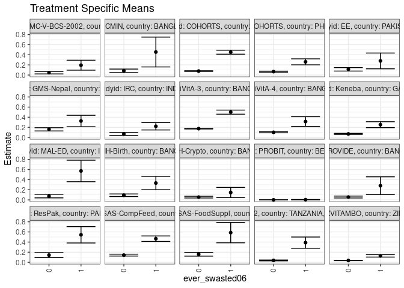

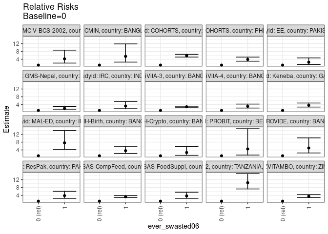

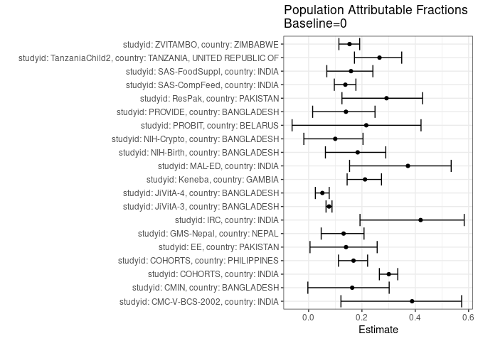

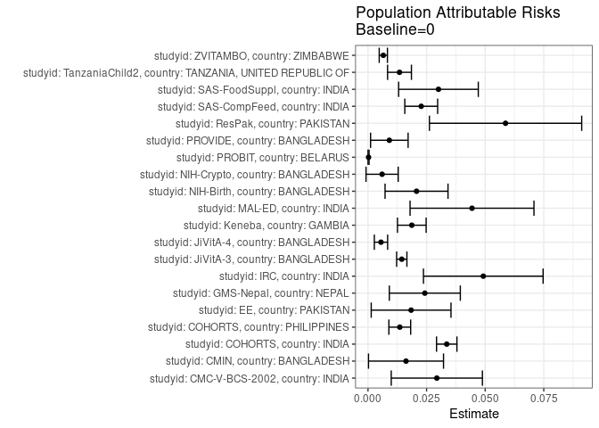

## Results Table

### Parameter: TSM

| studyid | country | intervention_level | baseline_level | estimate | ci_lower | ci_upper |
| --- | --- | --- | --- | --- | --- | --- |
| CMC-V-BCS-2002 | INDIA | 0 | NA | 0.0463051 | 0.0223740 | 0.0702363 |
| CMC-V-BCS-2002 | INDIA | 1 | NA | 0.1941167 | 0.0957365 | 0.2924969 |
| CMIN | BANGLADESH | 0 | NA | 0.0829876 | 0.0480898 | 0.1178853 |
| CMIN | BANGLADESH | 1 | NA | 0.4545455 | 0.1597077 | 0.7493832 |
| COHORTS | INDIA | 0 | NA | 0.0781258 | 0.0714970 | 0.0847546 |
| COHORTS | INDIA | 1 | NA | 0.4513089 | 0.4119213 | 0.4906964 |
| COHORTS | PHILIPPINES | 0 | NA | 0.0669271 | 0.0573211 | 0.0765331 |
| COHORTS | PHILIPPINES | 1 | NA | 0.2611346 | 0.2017167 | 0.3205524 |
| EE | PAKISTAN | 0 | NA | 0.1126222 | 0.0785746 | 0.1466697 |
| EE | PAKISTAN | 1 | NA | 0.2788536 | 0.1231714 | 0.4345358 |
| GMS-Nepal | NEPAL | 0 | NA | 0.1605022 | 0.1287683 | 0.1922360 |
| GMS-Nepal | NEPAL | 1 | NA | 0.3250148 | 0.2125107 | 0.4375190 |
| IRC | INDIA | 0 | NA | 0.0678801 | 0.0384799 | 0.0972803 |
| IRC | INDIA | 1 | NA | 0.2206912 | 0.1480185 | 0.2933639 |
| JiVitA-3 | BANGLADESH | 0 | NA | 0.1735995 | 0.1673171 | 0.1798818 |
| JiVitA-3 | BANGLADESH | 1 | NA | 0.5004047 | 0.4601179 | 0.5406914 |
| JiVitA-4 | BANGLADESH | 0 | NA | 0.1017360 | 0.0913741 | 0.1120979 |
| JiVitA-4 | BANGLADESH | 1 | NA | 0.3143167 | 0.2177888 | 0.4108445 |
| Keneba | GAMBIA | 0 | NA | 0.0696491 | 0.0587172 | 0.0805809 |
| Keneba | GAMBIA | 1 | NA | 0.2525368 | 0.1939766 | 0.3110969 |
| MAL-ED | INDIA | 0 | NA | 0.0747664 | 0.0394524 | 0.1100803 |
| MAL-ED | INDIA | 1 | NA | 0.5714286 | 0.3593206 | 0.7835366 |
| NIH-Birth | BANGLADESH | 0 | NA | 0.0918372 | 0.0662488 | 0.1174256 |
| NIH-Birth | BANGLADESH | 1 | NA | 0.3327015 | 0.2011759 | 0.4642271 |
| NIH-Crypto | BANGLADESH | 0 | NA | 0.0542522 | 0.0372404 | 0.0712640 |
| NIH-Crypto | BANGLADESH | 1 | NA | 0.1458333 | 0.0459197 | 0.2457470 |
| PROBIT | BELARUS | 0 | NA | 0.0008500 | 0.0002192 | 0.0014809 |
| PROBIT | BELARUS | 1 | NA | 0.0038402 | 0.0006414 | 0.0070391 |
| PROVIDE | BANGLADESH | 0 | NA | 0.0559322 | 0.0373752 | 0.0744892 |
| PROVIDE | BANGLADESH | 1 | NA | 0.2800000 | 0.1038524 | 0.4561476 |
| ResPak | PAKISTAN | 0 | NA | 0.1421584 | 0.0929182 | 0.1913985 |
| ResPak | PAKISTAN | 1 | NA | 0.5435374 | 0.3818805 | 0.7051943 |
| SAS-CompFeed | INDIA | 0 | NA | 0.1420298 | 0.1233682 | 0.1606914 |
| SAS-CompFeed | INDIA | 1 | NA | 0.4663436 | 0.4117601 | 0.5209271 |
| SAS-FoodSuppl | INDIA | 0 | NA | 0.1589836 | 0.1218392 | 0.1961280 |
| SAS-FoodSuppl | INDIA | 1 | NA | 0.5863598 | 0.3851090 | 0.7876106 |
| TanzaniaChild2 | TANZANIA, UNITED REPUBLIC OF | 0 | NA | 0.0371049 | 0.0287025 | 0.0455072 |
| TanzaniaChild2 | TANZANIA, UNITED REPUBLIC OF | 1 | NA | 0.3881546 | 0.2766214 | 0.4996878 |
| ZVITAMBO | ZIMBABWE | 0 | NA | 0.0360498 | 0.0323975 | 0.0397020 |
| ZVITAMBO | ZIMBABWE | 1 | NA | 0.1270952 | 0.1031616 | 0.1510288 |

### Parameter: E(Y)

| studyid | country | intervention_level | baseline_level | estimate | ci_lower | ci_upper |
| --- | --- | --- | --- | --- | --- | --- |
| CMC-V-BCS-2002 | INDIA | NA | NA | 0.0756757 | 0.0486905 | 0.1026609 |
| CMIN | BANGLADESH | NA | NA | 0.0992063 | 0.0622241 | 0.1361886 |
| COHORTS | INDIA | NA | NA | 0.1117237 | 0.1042858 | 0.1191617 |
| COHORTS | PHILIPPINES | NA | NA | 0.0804843 | 0.0704205 | 0.0905481 |
| EE | PAKISTAN | NA | NA | 0.1310160 | 0.0967738 | 0.1652583 |
| GMS-Nepal | NEPAL | NA | NA | 0.1847458 | 0.1534039 | 0.2160876 |
| IRC | INDIA | NA | NA | 0.1170732 | 0.0859146 | 0.1482317 |
| JiVitA-3 | BANGLADESH | NA | NA | 0.1880070 | 0.1814627 | 0.1945512 |
| JiVitA-4 | BANGLADESH | NA | NA | 0.1072724 | 0.0967392 | 0.1178055 |
| Keneba | GAMBIA | NA | NA | 0.0883377 | 0.0767324 | 0.0999430 |
| MAL-ED | INDIA | NA | NA | 0.1191489 | 0.0776405 | 0.1606574 |
| NIH-Birth | BANGLADESH | NA | NA | 0.1125461 | 0.0859151 | 0.1391771 |
| NIH-Crypto | BANGLADESH | NA | NA | 0.0602740 | 0.0429977 | 0.0775502 |
| PROBIT | BELARUS | NA | NA | 0.0010846 | 0.0004977 | 0.0016715 |
| PROVIDE | BANGLADESH | NA | NA | 0.0650407 | 0.0455353 | 0.0845460 |
| ResPak | PAKISTAN | NA | NA | 0.2008547 | 0.1494120 | 0.2522974 |
| SAS-CompFeed | INDIA | NA | NA | 0.1647399 | 0.1451050 | 0.1843747 |
| SAS-FoodSuppl | INDIA | NA | NA | 0.1890547 | 0.1507312 | 0.2273783 |
| TanzaniaChild2 | TANZANIA, UNITED REPUBLIC OF | NA | NA | 0.0505451 | 0.0409848 | 0.0601054 |
| ZVITAMBO | ZIMBABWE | NA | NA | 0.0425869 | 0.0387663 | 0.0464075 |

### Parameter: RR

| studyid | country | intervention_level | baseline_level | estimate | ci_lower | ci_upper |
| --- | --- | --- | --- | --- | --- | --- |
| CMC-V-BCS-2002 | INDIA | 0 | 0 | 1.000000 | 1.000000 | 1.000000 |
| CMC-V-BCS-2002 | INDIA | 1 | 0 | 4.192121 | 2.031070 | 8.652521 |
| CMIN | BANGLADESH | 0 | 0 | 1.000000 | 1.000000 | 1.000000 |
| CMIN | BANGLADESH | 1 | 0 | 5.477273 | 2.528380 | 11.865507 |
| COHORTS | INDIA | 0 | 0 | 1.000000 | 1.000000 | 1.000000 |
| COHORTS | INDIA | 1 | 0 | 5.776696 | 5.116629 | 6.521915 |
| COHORTS | PHILIPPINES | 0 | 0 | 1.000000 | 1.000000 | 1.000000 |
| COHORTS | PHILIPPINES | 1 | 0 | 3.901774 | 2.984804 | 5.100449 |
| EE | PAKISTAN | 0 | 0 | 1.000000 | 1.000000 | 1.000000 |
| EE | PAKISTAN | 1 | 0 | 2.476010 | 1.307773 | 4.687836 |
| GMS-Nepal | NEPAL | 0 | 0 | 1.000000 | 1.000000 | 1.000000 |
| GMS-Nepal | NEPAL | 1 | 0 | 2.024987 | 1.359229 | 3.016837 |
| IRC | INDIA | 0 | 0 | 1.000000 | 1.000000 | 1.000000 |
| IRC | INDIA | 1 | 0 | 3.251190 | 1.887704 | 5.599520 |
| JiVitA-3 | BANGLADESH | 0 | 0 | 1.000000 | 1.000000 | 1.000000 |
| JiVitA-3 | BANGLADESH | 1 | 0 | 2.882524 | 2.643105 | 3.143631 |
| JiVitA-4 | BANGLADESH | 0 | 0 | 1.000000 | 1.000000 | 1.000000 |
| JiVitA-4 | BANGLADESH | 1 | 0 | 3.089531 | 2.238987 | 4.263179 |
| Keneba | GAMBIA | 0 | 0 | 1.000000 | 1.000000 | 1.000000 |
| Keneba | GAMBIA | 1 | 0 | 3.625846 | 2.741661 | 4.795180 |
| MAL-ED | INDIA | 0 | 0 | 1.000000 | 1.000000 | 1.000000 |
| MAL-ED | INDIA | 1 | 0 | 7.642857 | 4.191447 | 13.936300 |
| NIH-Birth | BANGLADESH | 0 | 0 | 1.000000 | 1.000000 | 1.000000 |
| NIH-Birth | BANGLADESH | 1 | 0 | 3.622731 | 2.232372 | 5.879027 |
| NIH-Crypto | BANGLADESH | 0 | 0 | 1.000000 | 1.000000 | 1.000000 |
| NIH-Crypto | BANGLADESH | 1 | 0 | 2.688063 | 1.265352 | 5.710413 |
| PROBIT | BELARUS | 0 | 0 | 1.000000 | 1.000000 | 1.000000 |
| PROBIT | BELARUS | 1 | 0 | 4.517901 | 1.371594 | 14.881545 |
| PROVIDE | BANGLADESH | 0 | 0 | 1.000000 | 1.000000 | 1.000000 |
| PROVIDE | BANGLADESH | 1 | 0 | 5.006061 | 2.458188 | 10.194764 |
| ResPak | PAKISTAN | 0 | 0 | 1.000000 | 1.000000 | 1.000000 |
| ResPak | PAKISTAN | 1 | 0 | 3.823463 | 2.419318 | 6.042560 |
| SAS-CompFeed | INDIA | 0 | 0 | 1.000000 | 1.000000 | 1.000000 |
| SAS-CompFeed | INDIA | 1 | 0 | 3.283421 | 2.819055 | 3.824279 |
| SAS-FoodSuppl | INDIA | 0 | 0 | 1.000000 | 1.000000 | 1.000000 |
| SAS-FoodSuppl | INDIA | 1 | 0 | 3.688177 | 2.432750 | 5.591473 |
| TanzaniaChild2 | TANZANIA, UNITED REPUBLIC OF | 0 | 0 | 1.000000 | 1.000000 | 1.000000 |
| TanzaniaChild2 | TANZANIA, UNITED REPUBLIC OF | 1 | 0 | 10.461013 | 7.253760 | 15.086355 |
| ZVITAMBO | ZIMBABWE | 0 | 0 | 1.000000 | 1.000000 | 1.000000 |
| ZVITAMBO | ZIMBABWE | 1 | 0 | 3.525550 | 2.847741 | 4.364689 |

### Parameter: PAR

| studyid | country | intervention_level | baseline_level | estimate | ci_lower | ci_upper |
| --- | --- | --- | --- | --- | --- | --- |
| CMC-V-BCS-2002 | INDIA | 0 | NA | 0.0293705 | 0.0099187 | 0.0488224 |
| CMIN | BANGLADESH | 0 | NA | 0.0162188 | 0.0002139 | 0.0322237 |
| COHORTS | INDIA | 0 | NA | 0.0335980 | 0.0292460 | 0.0379499 |
| COHORTS | PHILIPPINES | 0 | NA | 0.0135572 | 0.0089088 | 0.0182056 |
| EE | PAKISTAN | 0 | NA | 0.0183939 | 0.0013728 | 0.0354149 |
| GMS-Nepal | NEPAL | 0 | NA | 0.0242436 | 0.0090933 | 0.0393939 |
| IRC | INDIA | 0 | NA | 0.0491930 | 0.0236683 | 0.0747178 |
| JiVitA-3 | BANGLADESH | 0 | NA | 0.0144075 | 0.0122153 | 0.0165996 |
| JiVitA-4 | BANGLADESH | 0 | NA | 0.0055363 | 0.0026972 | 0.0083755 |
| Keneba | GAMBIA | 0 | NA | 0.0186886 | 0.0125705 | 0.0248067 |
| MAL-ED | INDIA | 0 | NA | 0.0443826 | 0.0179485 | 0.0708166 |
| NIH-Birth | BANGLADESH | 0 | NA | 0.0207089 | 0.0072778 | 0.0341400 |
| NIH-Crypto | BANGLADESH | 0 | NA | 0.0060218 | -0.0008431 | 0.0128867 |
| PROBIT | BELARUS | 0 | NA | 0.0002346 | 0.0000115 | 0.0004577 |
| PROVIDE | BANGLADESH | 0 | NA | 0.0091084 | 0.0011028 | 0.0171141 |
| ResPak | PAKISTAN | 0 | NA | 0.0586963 | 0.0262043 | 0.0911883 |
| SAS-CompFeed | INDIA | 0 | NA | 0.0227101 | 0.0157049 | 0.0297153 |
| SAS-FoodSuppl | INDIA | 0 | NA | 0.0300711 | 0.0130791 | 0.0470631 |
| TanzaniaChild2 | TANZANIA, UNITED REPUBLIC OF | 0 | NA | 0.0134402 | 0.0083476 | 0.0185329 |
| ZVITAMBO | ZIMBABWE | 0 | NA | 0.0065371 | 0.0047849 | 0.0082894 |

### Parameter: PAF

| studyid | country | intervention_level | baseline_level | estimate | ci_lower | ci_upper |
| --- | --- | --- | --- | --- | --- | --- |
| CMC-V-BCS-2002 | INDIA | 0 | NA | 0.3881108 | 0.1212735 | 0.5739193 |
| CMIN | BANGLADESH | 0 | NA | 0.1634855 | -0.0027793 | 0.3021829 |
| COHORTS | INDIA | 0 | NA | 0.3007236 | 0.2653985 | 0.3343500 |
| COHORTS | PHILIPPINES | 0 | NA | 0.1684452 | 0.1119921 | 0.2213095 |
| EE | PAKISTAN | 0 | NA | 0.1403940 | 0.0052889 | 0.2571486 |
| GMS-Nepal | NEPAL | 0 | NA | 0.1312268 | 0.0472003 | 0.2078430 |
| IRC | INDIA | 0 | NA | 0.4201905 | 0.1928031 | 0.5835229 |
| JiVitA-3 | BANGLADESH | 0 | NA | 0.0766327 | 0.0653679 | 0.0877618 |
| JiVitA-4 | BANGLADESH | 0 | NA | 0.0516102 | 0.0252910 | 0.0772187 |
| Keneba | GAMBIA | 0 | NA | 0.2115588 | 0.1444934 | 0.2733668 |
| MAL-ED | INDIA | 0 | NA | 0.3724967 | 0.1536730 | 0.5347420 |
| NIH-Birth | BANGLADESH | 0 | NA | 0.1840037 | 0.0630238 | 0.2893629 |
| NIH-Crypto | BANGLADESH | 0 | NA | 0.0999067 | -0.0178485 | 0.2040388 |
| PROBIT | BELARUS | 0 | NA | 0.2162940 | -0.0619533 | 0.4216364 |
| PROVIDE | BANGLADESH | 0 | NA | 0.1400424 | 0.0151570 | 0.2490913 |
| ResPak | PAKISTAN | 0 | NA | 0.2922327 | 0.1250817 | 0.4274499 |
| SAS-CompFeed | INDIA | 0 | NA | 0.1378542 | 0.0963970 | 0.1774094 |
| SAS-FoodSuppl | INDIA | 0 | NA | 0.1590603 | 0.0682460 | 0.2410233 |
| TanzaniaChild2 | TANZANIA, UNITED REPUBLIC OF | 0 | NA | 0.2659055 | 0.1719486 | 0.3492014 |
| ZVITAMBO | ZIMBABWE | 0 | NA | 0.1535014 | 0.1136541 | 0.1915572 |